# Lecture 2: Intro to Data Analytics

Jesus Wladimir Avalos Quizhpi

2024-01-22

We begin by loading the data set of 20,000 observations into the R workspace.After launching RStudio, enter the following command.

```r
source("http://www.openintro.org/stat/data/cdc.R")
```

Now we are going to run basic summary prompts to analyze the dataset:

```r
names(cdc)
```

```
## [1] "genhlth"  "exerany"  "hlthplan" "smoke100" "height"   "weight"   "wtdesire"
## [8] "age"      "gender"
```

```r
summary(cdc$hlthplan)
```

```
##    Min. 1st Qu.  Median    Mean 3rd Qu.    Max.
##  0.0000  1.0000  1.0000  0.8738  1.0000  1.0000
```

```r
summary(cdc)
```

```
##       genhlth        exerany          hlthplan         smoke100
##  excellent:4657   Min.   :0.0000   Min.   :0.0000   Min.   :0.0000
##  very good:6972   1st Qu.:0.0000   1st Qu.:1.0000   1st Qu.:0.0000
##  good     :5675   Median :1.0000   Median :1.0000   Median :0.0000
##  fair     :2019   Mean   :0.7457   Mean   :0.8738   Mean   :0.4721
##  poor     : 677   3rd Qu.:1.0000   3rd Qu.:1.0000   3rd Qu.:1.0000
##                   Max.   :1.0000   Max.   :1.0000   Max.   :1.0000
##      height          weight         wtdesire          age        gender
##  Min.   :48.00   Min.   : 68.0   Min.   : 68.0   Min.   :18.00   m: 9569
##  1st Qu.:64.00   1st Qu.:140.0   1st Qu.:130.0   1st Qu.:31.00   f:10431
##  Median :67.00   Median :165.0   Median :150.0   Median :43.00
##  Mean   :67.18   Mean   :169.7   Mean   :155.1   Mean   :45.07
##  3rd Qu.:70.00   3rd Qu.:190.0   3rd Qu.:175.0   3rd Qu.:57.00
##  Max.   :93.00   Max.   :500.0   Max.   :680.0   Max.   :99.00
```

```r
head(cdc)
```

```
##     genhlth exerany hlthplan smoke100 height weight wtdesire age gender
## 1      good       0        1        0     70    175      175  77      m
## 2      good       0        1        1     64    125      115  33      f
## 3      good       1        1        1     60    105      105  49      f
## 4      good       1        1        0     66    132      124  42      f
## 5 very good       0        1        0     61    150      130  55      f
## 6 very good       1        1        0     64    114      114  55      f
```

```r
class(cdc)
```

```
## [1] "data.frame"
```

```r
str(cdc)
```

```
## 'data.frame':    20000 obs. of  9 variables:
##  $ genhlth : Factor w/ 5 levels "excellent","very good",..: 3 3 3 3 2 2 2 2 3 3 ...
##  $ exerany : num  0 0 1 1 0 1 1 0 0 1 ...
##  $ hlthplan: num  1 1 1 1 1 1 1 1 1 1 ...
##  $ smoke100: num  0 1 1 0 0 0 0 0 1 0 ...
##  $ height  : num  70 64 60 66 61 64 71 67 65 70 ...
##  $ weight  : int  175 125 105 132 150 114 194 170 150 180 ...
##  $ wtdesire: int  175 115 105 124 130 114 185 160 130 170 ...
##  $ age     : int  77 33 49 42 55 55 31 45 27 44 ...
##  $ gender  : Factor w/ 2 levels "m","f": 1 2 2 2 2 2 1 1 2 1 ...
```

```r
class(cdc$gender)
```

```
## [1] "factor"
```

```r
str(cdc$gender)
```

```
##  Factor w/ 2 levels "m","f": 1 2 2 2 2 2 1 1 2 1 ...
```

The data set cdc that shows up in your workspace is a data matrix, with each row representing a case and each column representing a variable. R calls this data format a data frame, which is a term that will be used throughout the labs.

To view the names of the variables, type the command Each of these variables corresponds to questions asked in the survey will see the possible responses also later.

```r
names(cdc)
```

```
## [1] "genhlth"  "exerany"  "hlthplan" "smoke100" "height"   "weight"   "wtdesire"
## [8] "age"      "gender"
```

Some Questions here we want to answer first:

How many cases are there in this data set?: *There are 20000 observations (cases) in the data set “cdc”.*

```r
nrow(cdc)
```

```
## [1] 20000
```

How many variables?: *There are 9 variables in the data set cdc.*

```r
length(names(cdc))
```

```
## [1] 9
```

For each variable, identify its data type (e.g. categorical, discrete):

```r
str(cdc)
```

```
## 'data.frame':    20000 obs. of  9 variables:
##  $ genhlth : Factor w/ 5 levels "excellent","very good",..: 3 3 3 3 2 2 2 2 3 3 ...
##  $ exerany : num  0 0 1 1 0 1 1 0 0 1 ...
##  $ hlthplan: num  1 1 1 1 1 1 1 1 1 1 ...
##  $ smoke100: num  0 1 1 0 0 0 0 0 1 0 ...
##  $ height  : num  70 64 60 66 61 64 71 67 65 70 ...
##  $ weight  : int  175 125 105 132 150 114 194 170 150 180 ...
##  $ wtdesire: int  175 115 105 124 130 114 185 160 130 170 ...
##  $ age     : int  77 33 49 42 55 55 31 45 27 44 ...
##  $ gender  : Factor w/ 2 levels "m","f": 1 2 2 2 2 2 1 1 2 1 ...
```

```r
dim(cdc)
```

```
## [1] 20000     9
```

```r
nrow(cdc)
```

```
## [1] 20000
```

```r
ncol(cdc)
```

```
## [1] 9
```

START at Looking at a few rows at top and bottom:

```r
head(cdc)
```

```
##     genhlth exerany hlthplan smoke100 height weight wtdesire age gender
## 1      good       0        1        0     70    175      175  77      m
## 2      good       0        1        1     64    125      115  33      f
## 3      good       1        1        1     60    105      105  49      f
## 4      good       1        1        0     66    132      124  42      f
## 5 very good       0        1        0     61    150      130  55      f
## 6 very good       1        1        0     64    114      114  55      f
```

```r
tail(cdc,10)
```

```
##         genhlth exerany hlthplan smoke100 height weight wtdesire age gender
## 19991 excellent       1        1        0     71    195      190  43      m
## 19992 very good       1        1        1     72    210      175  52      m
## 19993 very good       1        1        0     71    180      180  36      m
## 19994 very good       0        1        1     63    165      120  31      f
## 19995      good       0        1        1     69    224      224  73      m
## 19996      good       1        1        0     66    215      140  23      f
## 19997 excellent       0        1        0     73    200      185  35      m
## 19998      poor       0        1        0     65    216      150  57      f
## 19999      good       1        1        0     67    165      165  81      f
## 20000      good       1        1        1     69    170      165  83      m
```

Look at the variables as Summaries and Tables:

### Summary and table functions:

A good first step in any analysis is to distill all of that information into a few summary statistics and graphics.

```r
str(cdc)
```

```
## 'data.frame':    20000 obs. of  9 variables:
##  $ genhlth : Factor w/ 5 levels "excellent","very good",..: 3 3 3 3 2 2 2 2 3 3 ...
##  $ exerany : num  0 0 1 1 0 1 1 0 0 1 ...
##  $ hlthplan: num  1 1 1 1 1 1 1 1 1 1 ...
##  $ smoke100: num  0 1 1 0 0 0 0 0 1 0 ...
##  $ height  : num  70 64 60 66 61 64 71 67 65 70 ...
##  $ weight  : int  175 125 105 132 150 114 194 170 150 180 ...
##  $ wtdesire: int  175 115 105 124 130 114 185 160 130 170 ...
##  $ age     : int  77 33 49 42 55 55 31 45 27 44 ...
##  $ gender  : Factor w/ 2 levels "m","f": 1 2 2 2 2 2 1 1 2 1 ...
```

```r
summary(cdc)
```

```
##       genhlth        exerany          hlthplan         smoke100
##  excellent:4657   Min.   :0.0000   Min.   :0.0000   Min.   :0.0000
##  very good:6972   1st Qu.:0.0000   1st Qu.:1.0000   1st Qu.:0.0000
##  good     :5675   Median :1.0000   Median :1.0000   Median :0.0000
##  fair     :2019   Mean   :0.7457   Mean   :0.8738   Mean   :0.4721
##  poor     : 677   3rd Qu.:1.0000   3rd Qu.:1.0000   3rd Qu.:1.0000
##                   Max.   :1.0000   Max.   :1.0000   Max.   :1.0000
##      height          weight         wtdesire          age        gender
##  Min.   :48.00   Min.   : 68.0   Min.   : 68.0   Min.   :18.00   m: 9569
##  1st Qu.:64.00   1st Qu.:140.0   1st Qu.:130.0   1st Qu.:31.00   f:10431
##  Median :67.00   Median :165.0   Median :150.0   Median :43.00
##  Mean   :67.18   Mean   :169.7   Mean   :155.1   Mean   :45.07
##  3rd Qu.:70.00   3rd Qu.:190.0   3rd Qu.:175.0   3rd Qu.:57.00
##  Max.   :93.00   Max.   :500.0   Max.   :680.0   Max.   :99.00
```

```r
class(cdc)
```

```
## [1] "data.frame"
```

If you want to look at a specific variable:

```r
summary(cdc$weight)
```

```
##    Min. 1st Qu.  Median    Mean 3rd Qu.    Max.
##    68.0   140.0   165.0   169.7   190.0   500.0
```

R also has built-in functions to compute summary statistics one by one. For instance, to calculate the mean, median, and variance of weight, type

NUMERIC VARIABLES STATS:

```r
mean(cdc$weight)
```

```
## [1] 169.683
```

```r
var(cdc$weight)
```

```
## [1] 1606.484
```

```r
median(cdc$weight)
```

```
## [1] 165
```

```r
sd(cdc$weight)
```

```
## [1] 40.08097
```

While it makes sense to describe a quantitative variable like weight in terms of these statistics, what about categorical data? We would instead consider the sample frequency or relative frequency distribution. The function table does this for you by counting the number of times each kind of response was given. For example, to see the number of people who have smoked 100 cigarettes in their lifetime, type:

```r
#CATEGORICAL/Integral Numbers VARIABLE  STATS
table(cdc$smoke100)
```

```
##
##     0     1
## 10559  9441
```

```r
table(cdc$gender)
```

```
##
##     m     f
##  9569 10431
```

```r
table(cdc$genhlth)
```

```
##
## excellent very good      good      fair      poor
##      4657      6972      5675      2019       677
```

Or instead look at the relative frequency distribution by typing:

```r
numRows <- nrow(cdc)
table(cdc$smoke100)/numRows
```

```
##
##       0       1
## 0.52795 0.47205
```

Notice how R automatically divides all entries in the table by 20,000 in the command above. This is similar to something we observed in the Introduction to R; when we multiplied or divided a vector with a number, R applied that action across entries in the vectors.

As we see above, this also works for tables.

Next, we make a bar plot of the entries in the table by putting the table inside the barplot() command.

We saw plot() command last time.

```r
barplot(table(cdc$smoke100))
```

[output not shown]

[figure not shown]

```r
barplot(cdc$smoke100)
```

Can we directly write: table(cdc$smoke100)/nrows(cdc)? Let’s check it out:

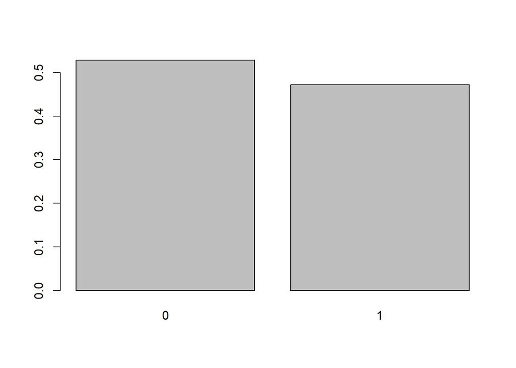

```r
barplot(table(cdc$smoke100)/nrow(cdc))
```

Notice what we’ve done here! We’ve computed the table of cdc$smoke100 and then immediately applied the graphical function, barplot. This is an important idea: R commands can be nested.You could also break this into two steps by typing the following:

```r
smoke <- table(cdc$smoke100)
barplot(smoke)
```

[output not shown]

Here, we’ve made a new object, a table, called smoke (the contents of which we can see by typing smoke into the console) and then used it in as the input for barplot.

The special symbol <- or = performs an assignment, taking the output of one line of code and saving it into an object in your workspace. This is another important idea that we’ll return to later.